# Plotting taxonomic trees

Trees

Animalia

Chordata

As of version 1.3.1 of `galah`, it is now possible to download taxonomic data using a ‘tree’ format from the `data.tree` package. Here I’ll demonstrate some ideas for plotting these trees using circular diagrams.

Martin Westgate  
2021-08-24

[figure not shown]

#### Author:

Martin Westgate

#### Date:

Taxonomy is pretty important at the ALA. Every occurrence record in the atlas is linked to a unique taxonomic identifier. These identifiers are themselves drawn from expertly curated taxonomic datasets. This system of classification is so important to our system that we have a special name for it; the ‘taxonomic backbone’. But what does it look like?

Visualising trees is not particularly easy for me; I didn’t train in it, and the data structures involved are a bit complex. More importantly, until recently it was difficult to download detailed taxonomic information from the ALA. With the release of version 1.3.1 - and the wonderful new function `ala_taxonomy` - I decided it was time to give it a go. This is just a quick test, however, so I won’t guarantee this is the best approach in the world. What do we need to do?

# Download and prune a tree

First we load the required packages, as well as some bespoke functions written for this post.

```r
library(galah)
library(data.tree)
library(stringr)
library(ggplot2)
library(viridisLite)
source("functions.R")
```

Then we can choose a taxonomic group to represent in tree form. I’ve chosen the chordates because they aren’t too large a group and the names are fairly well-known. Note that we also have to choose how far ‘down’ the tree to travel. I’ve chosen the Order level here; bear in mind that trying to traverse too many levels (i.e. choosing “genus” or “species” here) would take a *very* long time.

```r
chordata <- select_taxa("chordata")
chordate_orders <- ala_taxonomy(taxa = chordata, down_to = "order")
```

For the purpose of this exercise, I’m going to restrict the plot to data from the [Australian Faunal Directory](https://biodiversity.org.au/afd/home)

```r
Prune(chordate_orders, pruneFun = function(a){a$authority == "AFD"})
```

```
[1] 34
```

Next there are a few steps that are needed. First, subsetting to AFD taxonomy could have left us branches with no ‘leaves’ (orders), so we need to remove these where they occur. Second, if we are going to plot these nodes as segments of a circle, we’ll need to know where each segment should start and finish. We can do this by assigning each leaf to an integer, then calculating the minimum and maximum values of leaves within each parent node. These tasks are a bit convoluted, so I’ve written some functions that do these things for us:

```r
tree <- prep_tree(prune_leafless_branches(chordate_orders))
```

No we’re ready to calculate a few `data.frame`s that we’ll use to do the actual plotting.

# Building data.frames

Our next step is to extract a `data.frame` with 1 row per node (i.e. not just leaves) and containing all the node-level data that we’ll need late. Critically, this should include `leaf_min` and `leaf_max` (calculated above using `prep_tree()`). Fortunately, this is fairly straightforward using `data.tree`; we just tell the `ToDataFrameTree` function what columns (i.e. node attributes) we want to extract:

```r
tree_df <- ToDataFrameTree(tree,
   "name", "rank", "level", "is_leaf", "leaf_min", "leaf_max")
```

To plot this as a circle, we need to convert our `leaf_min` and `leaf_max` to locations around a circle (in degrees).

```r
max_value <- max(tree_df$leaf_max)
tree_df$segment_start <- ((tree_df$leaf_min - 1) * 360) / max_value
tree_df$segment_end <- ((tree_df$leaf_max) * 360) / max_value
```

Now we can create all the `data.frame`s we need. Specifically, we need three `data.frame`s that contain information on:

- the coordinates of each segment, to pass to `geom_polygon`
- rotated text to fill each segment, to plot with `geom_text`
- more rotated text to display leave names (Orders), again with `geom_text`

Again, I’ve created functions that do the heavy lifting here.

```r
# subset to only 'higher' nodes for drawing segments
df_higher <- tree_df[!tree_df$is_leaf, ]
df_higher <- df_higher[-1, ] # remove root
segment_df <- get_segments(df_higher)
segment_df$rank_factor <- factorize_ranks(segment_df) # optional

# calculate rotated text for segments
segment_text_df <- get_segment_text(df_higher)

# calculate rotated text for leaves
leaf_text_df <- get_leaf_text(tree_df)
```

# Plot

Finally, we can draw our plot. I’ve chosen to use the `viridis` colour palette, and to color segments by rank.

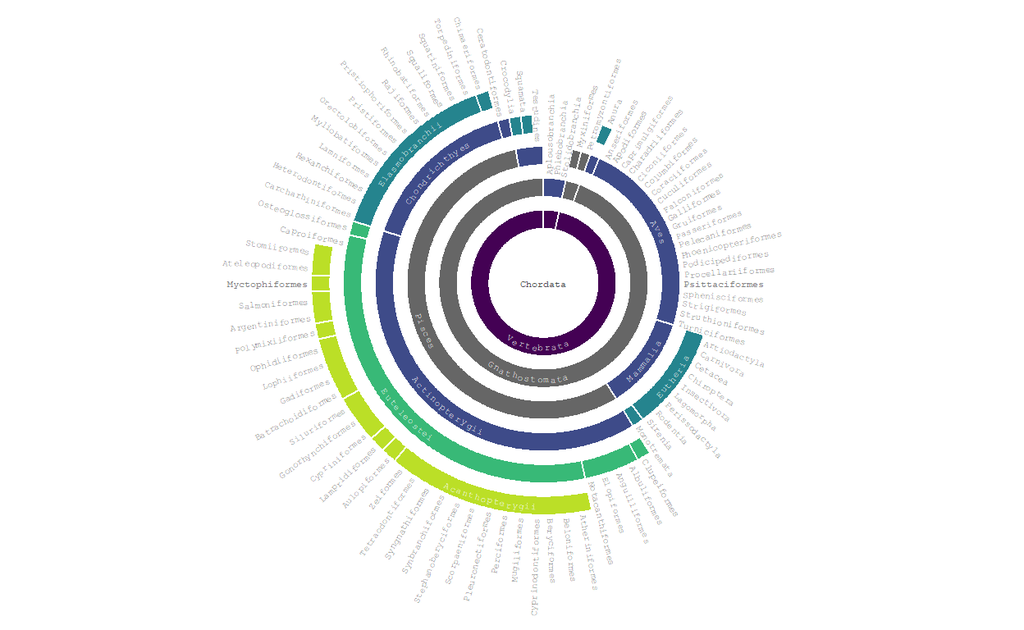

```r
ggplot() +
  geom_polygon(
    data = segment_df,
    mapping = aes(x = x, y = y, group = group, fill = rank_factor),
    color = "white"
  ) +
  # label the root node in the centre of the plot
  geom_text(
    data = tree_df[1, ],
    mapping = aes(label = name),
    x = 0,
    y = 0,
    hjust = 0.5,
    size = 1.5,
    color = "grey30",
    family = "mono") +
  # segment text
  geom_text(
    data = segment_text_df,
    mapping = aes(x = x, y = y, label = label, angle = rotation),
    size = 1.5,
    color = "white",
    family = "mono") +
  # leaf text
  geom_text(
    data = leaf_text_df,
    mapping = aes(x = x, y = y, label = label, angle = rotation, hjust = hjust),
    size = 1.5,
    color = "grey50",
    family = "mono") +
  lims(x = c(-10, 8), y = c(-10, 8))+
  labs(fill = "Rank") +
  scale_fill_manual(values = c(viridis(5, begin = 0, end = 0.9), "grey40")) +
  coord_fixed() +
  theme_void() +
  theme(legend.position = "none")
```

In future, there are several things you could do to improve this kind of plot:

- show level in the taxonomic hierarchy by radius of each segment, rather than colour
- support variable letter spacing for segment text, reducing dependence on monospaced fonts
- potentially add marginal barplots or similar, e.g. to show number of records or species in each terminal node
- package this up so it’s easier to reproduce

While those are great ideas, that’s all for now - I hope you found this helpful!

See the [original R script](https://github.com/AtlasOfLivingAustralia/science/blob/main/comms/2021-08-24_taxonomy/taxonomy_plot_code.R)